# Question

The following equation (in polynomial form) represents an ellipse.

$$49x^2-392x+4y^2-24y+624=0$$

With some algebra ([completing the square](https://en.wikipedia.org/wiki/Completing_the_square)), you can convert the equation into standard form:

$$\frac{(x-h)^2}{(r_1)^2}+\frac{(y-k)^2}{(r_2)^2}=1$$

From the given polynomial form, determine the 4 parameters.

- $h=$ ##ANSWER1##
- $k=$ ##ANSWER2##
- $r_1=$ ##ANSWER3##
- $r_2=$ ##ANSWER4##

## Answerlist

- -10
- -9
- -8
- -7
- -6
- -5
- -4
- -3
- -2
- -1
- 0
- 1
- 2
- 3
- 4
- 5
- 6
- 7
- 8
- 9
- 10
- -10
- -9
- -8
- -7
- -6
- -5
- -4
- -3
- -2
- -1
- 0
- 1
- 2
- 3
- 4
- 5
- 6
- 7
- 8
- 9
- 10
- 1
- 2
- 3
- 4
- 5
- 6
- 7
- 8
- 9
- 10
- 1
- 2
- 3
- 4
- 5
- 6
- 7
- 8
- 9
- 10

# Solution

$$49x^2-392x+4y^2-24y+624=0$$
Factor out the quadratic coefficients from each variable’s polynomial. Also move the constant term to the right with addition/subtration.

$$49(x^2-8x)+4(y^2-6y)=-624$$

Complete the square for the $x$ quadratic. If $x^2+bx+c$ is a perfect square, then $c=\left(\frac{b}{2}\right)^2$. In this case, the linear coefficient is $-8$. If you divide it by 2 and square the result, you get the necessary constant to complete the square (16). Notice $(x-4)^2\equiv x^2-8x+16$. Lastly, since we are adding 16 inside parentheses with a multiplier of 49, we are technically adding 784 to both sides to make an equivalent equation.

$$49(x^2-8x+16)+4(y^2-6y)=-624+784$$

Complete the square for the $y$ quadratic. If $y^2+by+c$ is a perfect square, then $c=\left(\frac{b}{2}\right)^2$. In this case, the linear coefficient is $-6$. If you divide it by 2 and square the result, you get the necessary constant to complete the square (9). Notice $(y-3)^2\equiv y^2-6x+9$. Lastly, since we are adding 9 inside parentheses with a multiplier of 4, we are technically adding 36 to both sides to make an equivalent equation.

$$49(x^2-8x+16)+4(y^2-6y+9)=-624+784+36$$

Combine the constants.

$$49(x^2-8x+16)+4(y^2-6y+9)=196$$

O yeah, remember how you completed the square? Twice? Let’s rewrite those quadratic expressions in factored form. (This could have been done earlier.)

$$49(x-4)^2+4(y-3)^2=196$$

Divide both sides by $196$.

$$\frac{49(x-4)^2}{196}+\frac{4(y-3)^2}{196}=1$$

Simplify the fractions. Notice that $\frac{49}{196}= \frac{1}{4}$ and $\frac{4}{196}= \frac{1}{49}$.

$$\frac{(x-4)^2}{4}+\frac{(y-3)^2}{49}=1$$

If you find the square roots of both denominators, you will have the standard form of an ellipse. Notice $\sqrt{4}=2$ and $\sqrt{49}=7$.

$$\frac{(x-4)^2}{2^2}+\frac{(y-3)^2}{7^2}=1$$

Thus,

$$\begin{align}
h &= 4 \\
k &= 3 \\
r_1 &= 2 \\
r_2 &= 7
\end{align}$$

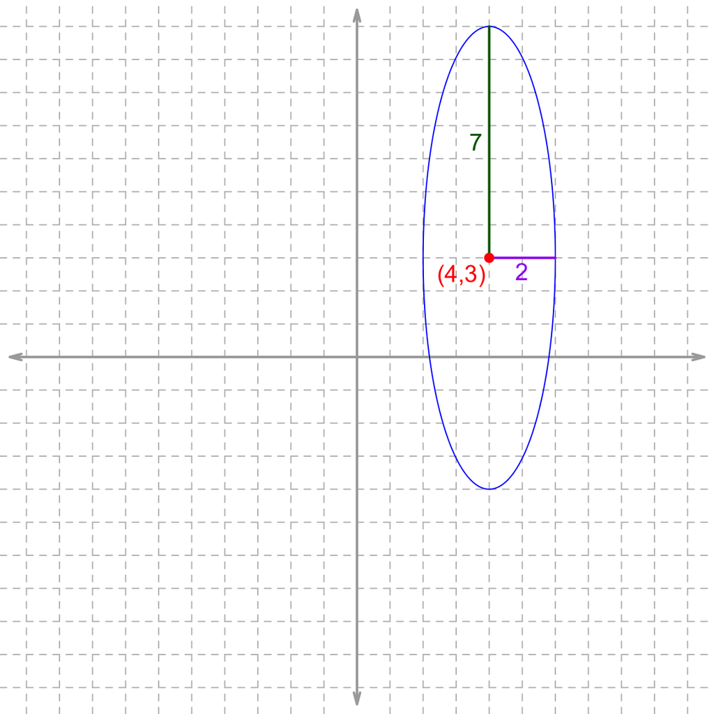

# Meta-information

extype: cloze exclozetype: schoice|schoice|schoice|schoice exsolution: 000000000000001000000|000000000000010000000|0100000000|0000001000 exname: polynom_to_stndrd_ell